# Praca domowa 2

Maciej Orłowski

## Dane

Dane wykorzystane w Pracy domowej 2 dotyczą wyników egzaminów z 3 umiejętności: czytania, pisania i operacji matematycznych. Dodatkowo dostępne są podstawowe informacje o studentach i ich rodzicach. Opis wszystkich kolumn znajduje się również w pliku `README.md`.

| Zmienna | Opis |
| --- | --- |
| **gender** | płeć |
| **race.ethnicity** | pochodzenie etniczne |
| **parental.level.of.education** | wykształcenie rodziców |
| **lunch** | jaki obiad jedli uczniowie w dniu egzaminu |
| **test.preparation.course** | czy uczeń odbył kurs przygotowujący |
| **math.score** | wynik egzaminu z matematyki |
| **reading.score** | wynik egzaminu z czytania |
| **writing.score** | wynik egzaminu z pisania |

## Zadanie 1

Jak wyglądają rozkłady wyników uczniów z trzech przedmiotów (matematyka, czytanie, pisanie)?

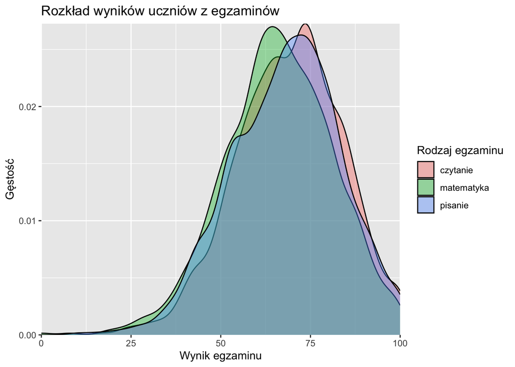

```r
plot_1_data <- df %>%
  pivot_longer(
    cols = c(math.score, reading.score, writing.score),
    names_to = 'exam_type',
    values_to = 'score'
  ) %>%
  mutate(exam_type = case_when(
    exam_type == 'math.score' ~ 'matematyka',
    exam_type == 'reading.score' ~ 'czytanie',
    exam_type == 'writing.score' ~ 'pisanie'
  ))

plot_1 <- ggplot(plot_1_data, aes(x = score, fill = exam_type)) +
  geom_density(adjust=0.8, alpha=0.4) +
  xlim(min(plot_1_data$score), max(plot_1_data$score)) +
  labs(
    title = "Rozkład wyników uczniów z egzaminów",
    x = "Wynik egzaminu",
    y = "Gęstość",
    fill = "Rodzaj egzaminu"
  ) +
  scale_y_continuous(expand = c(0,0)) +
  scale_x_continuous(expand = c(0,0))

plot_1
```

**Komentarz:**

Z wyrkesu możemy wyczytać, że dla każdego z egzaminów najwięcej osób zdobywało wyniki pomiędzy 50, a 80. Wyniki egzaminów z czytania i pisania są dość podobne (mniej więcej podobna ilość osób miała podobne wyniki), z kolei z matematyki można powiedzieć, że te wyniki są trochę niższe (wykres jest przesunięty na lewo, co oznacza, że moda tych wyników jest mniejsza).

## Zadanie 2

Czy istnieje zauważalna różnica w wynikach między uczniami i uczennicami?

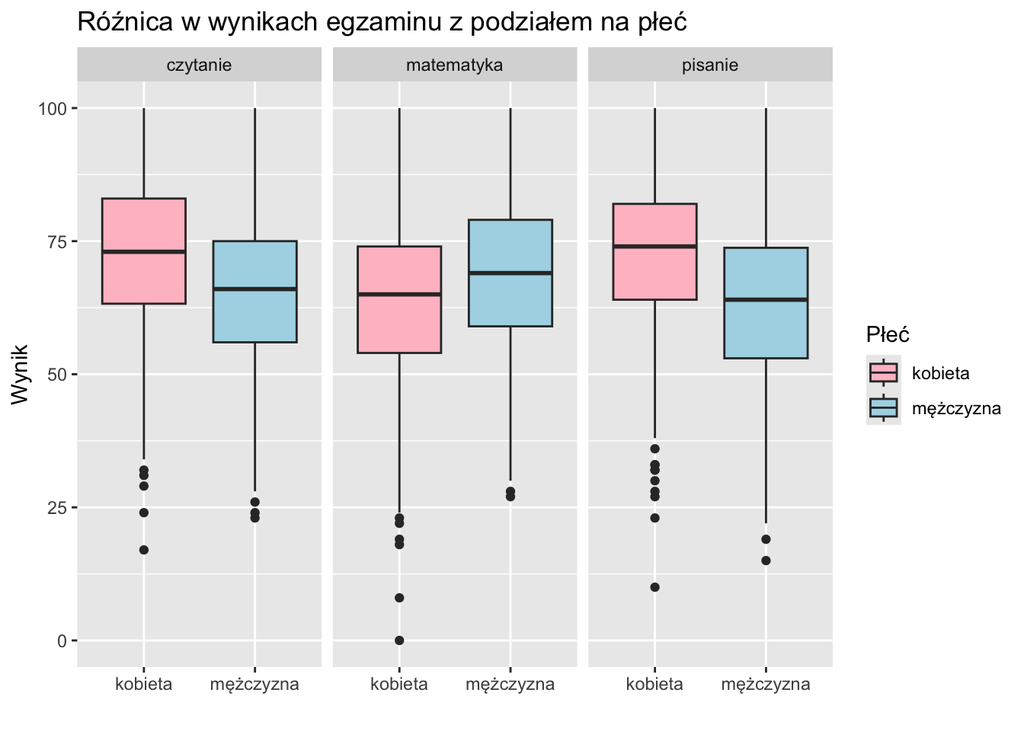

```r
plot_2_data <- plot_1_data %>%
  mutate(gender = ifelse(gender == "male", "mężczyzna", "kobieta"))

plot_2 <- ggplot(plot_2_data, aes(x = gender, y = score, fill = gender)) +
  geom_boxplot() +
  facet_grid(cols = vars(exam_type)) +
  labs(
    title = "Róźnica w wynikach egzaminu z podziałem na płeć",
    x = "",
    y = "Wynik",
    fill = "Płeć"
  ) +
  scale_fill_manual(values = c("kobieta" = "pink", "mężczyzna" = "lightblue"))


plot_2
```

**Komentarz:**

Widać, że średnio uczennice radzą sobie lepiej w przedmiotach humanistycznych (czytanie, pisanie), za to uczniowie w przedmiotach ścisłych (matematyka). W przypadku matematyki widzimy, że minimalny wynik uzyskiwany przez uczennice (okolice 0) jest zancznie mniejszy niż minimalny wynik uzyskiwany przez uczniów (okolice 25). w pozostałych przedmiotach także widzimy, że uczennice osiągają mniejsze minimalne wyniki, jednak ta różnica nie jest już taka duża.

## Zadanie 3

Czy uczniowie, którzy ukończyli kurs przygotowawczy, osiągają lepsze wyniki niż pozostali?

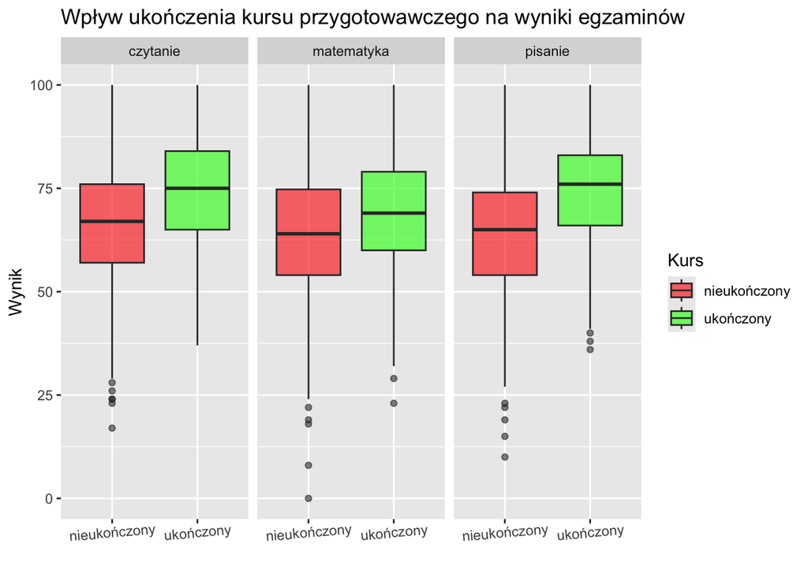

```r
plot_3_data <- plot_1_data %>%
  mutate(test.preparation.course = ifelse(test.preparation.course == "completed", "ukończony", "nieukończony"))

plot_3 <- ggplot(plot_3_data, aes(x = test.preparation.course, y = score, fill = test.preparation.course)) +
  geom_boxplot(alpha = 0.6) +
  facet_grid(cols = vars(exam_type)) +
  labs(title = "Wpływ ukończenia kursu przygotowawczego na wyniki egzaminów",
    x = "",
    y = "Wynik",
    fill = "Kurs") +
  theme(axis.text.x = element_text(angle = 5))+
  scale_fill_manual(values = c("nieukończony" = "red", "ukończony" = "green"))

plot_3
```

**Komentarz:**

Z wykresów widać, że ukończenie kursów przygotowawczych pozwala średnio uzyskać lepsze wyniki (największa różnica jest widoczna dla przedmiotów humanistycznych). Możemy zauważyć, że minimalne wyniki uzyskiwane przez uczniów i uczennice są dużo wyższe po ukończeniu kursów, jednak nieukończenie kursu nie wyklucza uzyskanie maksymalnego wyniku.

## Zadanie 4

Jaki jest związek między poziomem wykształcenia rodziców a średnimi wynikami uczniów?

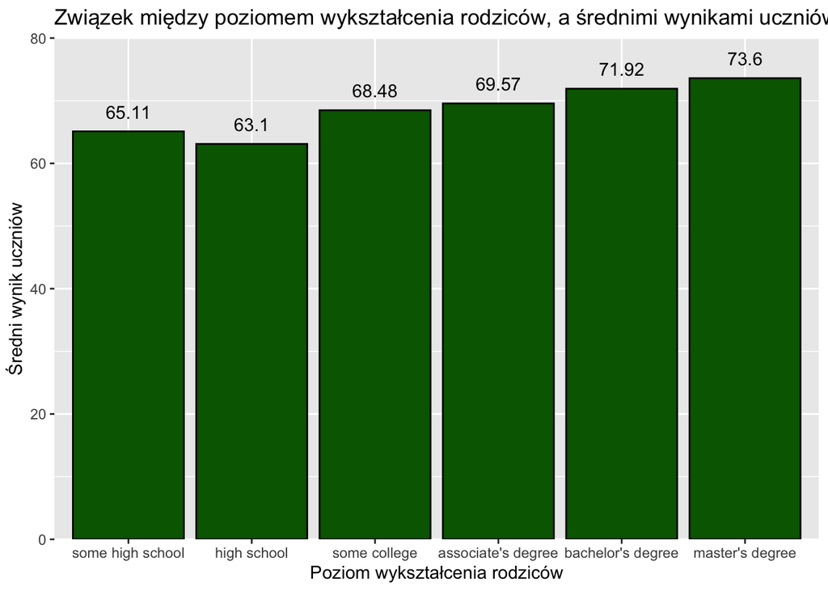

```r
plot_4_data <- df %>%
  group_by(parental.level.of.education) %>%
  summarise(avg_math_score = mean(math.score),
            avg_reading_score = mean(reading.score),
            avg_writing_score = mean(writing.score)) %>%
  mutate(avg_score = (avg_math_score + avg_reading_score + avg_writing_score)/3,
         avg_score = round(avg_score, 2),
         parental.level.of.education = fct_relevel(parental.level.of.education,
                                                   "some high school",
                                                   "high school",
                                                   "some college",
                                                   "associate's degree",
                                                   "bachelor's degree",
                                                   "master's degree"))


plot_4 <- ggplot(plot_4_data, aes(x = parental.level.of.education, y = avg_score)) +
  geom_col(fill = "darkgreen", color = "black") +
  scale_y_continuous(expand = c(0,0), limits = c(0,80)) +
  geom_text(aes(label = avg_score), vjust = -1) +
  labs(title = "Związek między poziomem wykształcenia rodziców, a średnimi wynikami uczniów",
       x = "Poziom wykształcenia rodziców",
       y = "Średni wynik uczniów")

plot_4
```

**Komentarz:**

(Ze względu na brak polskich odpowiedników niektórych nazw poziomu wykształcenia zostawiłem te nazwy w oryginale.)

Z wykresu widać, że średnio im wyższe wykształcenie rodzica, tym średni wynik z egzaminu jest wyższy. Jedynym odstępstwem od reguły jest to, czy ktoś ukończył jedynie liceum (high school), czy też skończył swoją edukację, bez ukończenia liceum (some high school).

## Zadanie 5

Czy płeć i wykształcenie rodzica wpływa na wynik z matematyki?

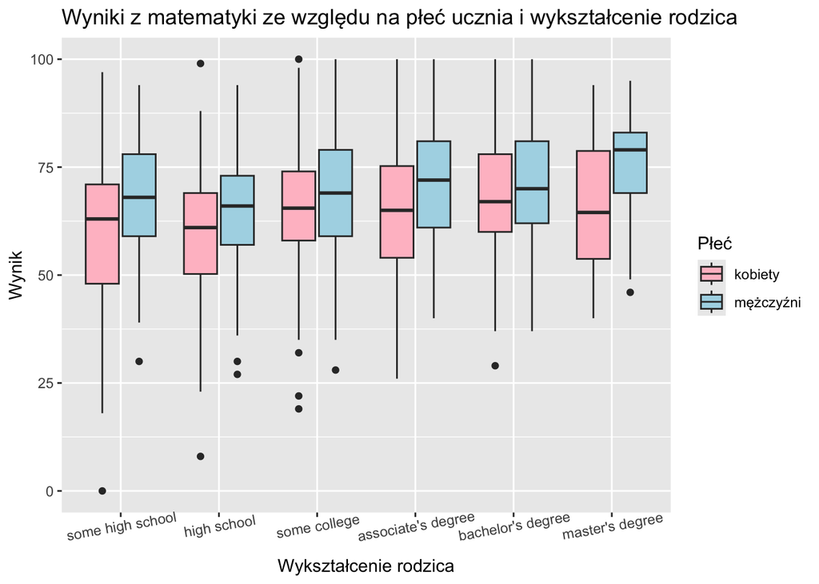

```r
plot_5_data <- df %>%
  mutate(parental.level.of.education = fct_relevel(parental.level.of.education,
                                                   "some high school",
                                                   "high school",
                                                   "some college",
                                                   "associate's degree",
                                                   "bachelor's degree",
                                                   "master's degree"),
         gender = ifelse(gender == "male", "mężczyźni", "kobiety"))

plot_5 <- ggplot(plot_5_data, aes(x = parental.level.of.education, y = math.score, fill = gender)) +
  geom_boxplot() +
  labs(title = "Wyniki z matematyki ze względu na płeć ucznia i wykształcenie rodzica",
       x = "Wykształcenie rodzica",
       y = "Wynik",
       fill = "Płeć") +
  scale_fill_manual(values = c("kobiety" = "pink", "mężczyźni" = "lightblue")) +
  theme(axis.text.x = element_text(angle = 10))

plot_5
```

**Komentarz:**

Z wykresu możemy wyczytać, że większy wpływ na wyniki z egzaminu z matematyki ma płeć, niż wykształcenie rodzica. Widać jednak, że wraz ze wzrostem poziomu wykształcenia rodzica rozrzut wyników jest dużo mniejszy. Co ciekawe dla grupy uczniów/uczennic, których rodzice są najbardziej wykształceni nie widzimy uzyskanych maksymalnych wyników (pomimo, że średni wynik dla uczniów jest największy właśnie dla tej grupy).

## Zadanie 6

Czy istnieje zależność między wynikami z matematyki a wynikami z czytania lub pisania?

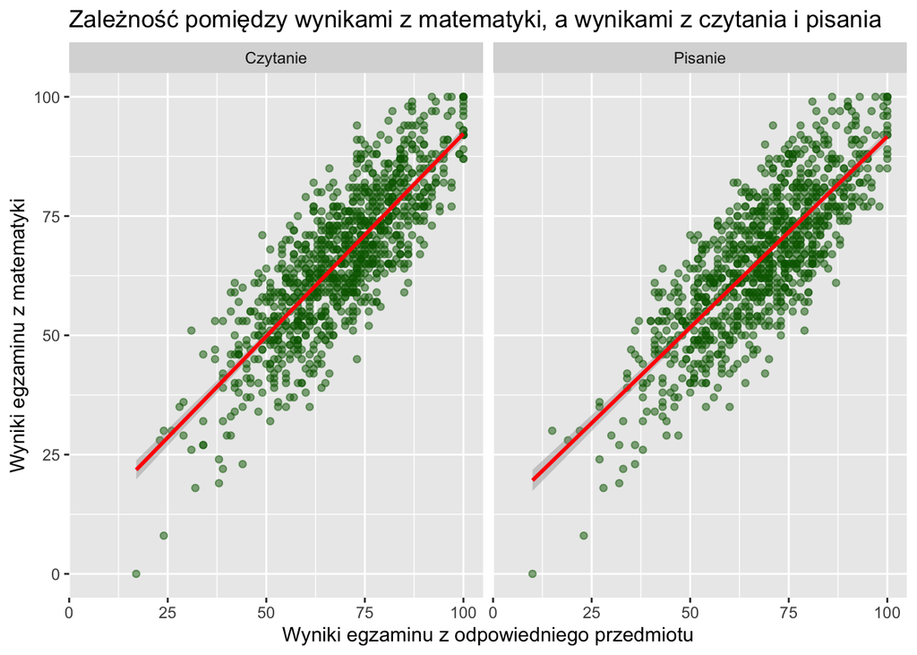

```r
plot_6_data <- df %>%
  pivot_longer(cols = c(reading.score, writing.score),
    names_to = 'exam_type',
    values_to = 'score') %>%
  mutate(exam_type = ifelse(exam_type == "reading.score", "Czytanie", "Pisanie"))

plot_6 <- ggplot(plot_6_data, aes(x = score, y = math.score)) +
  geom_point(color = "darkgreen", alpha = 0.5) +
  geom_smooth(method = "lm", color = "red") +
  facet_grid(cols = vars(exam_type)) +
  scale_x_continuous(expand = c(0,0), limits = c(0,105)) +
  labs(title = "Zależność pomiędzy wynikami z matematyki, a wynikami z czytania i pisania",
       x = "Wyniki egzaminu z odpowiedniego przedmiotu",
       y = "Wyniki egzaminu z matematyki")

plot_6
```

**Komentarz:**

Tak, widzimy zależnośc pomiędzy wynikami z matematyki i wynikami z czytania i pisania. Widzimy, że im większe wyniki z matematyki, tym też większe wyniki z odpowiednich przedmiotów. Prosta dopasowana do danych w obu przypadkach ma podobny współczynnik kierunkowy.